# Information Management Database Project Report

## Data Analysis 6 -- Exploring the Stock Price of S&P Companies by Sectors

```python
%%sql result_set6 <<
select sp.symbol, sp.sector, sp.sectorid, s.date, s.adjustedclose
from sp500withgics sp
join sp500stockprice s
on sp.symbol = s.symbol;
```

```
 * postgresql://postgres:***@127.0.0.1:5433/6354Database
661196 rows affected.
Returning data to local variable result_set6
```

```python
df6 = result_set6.DataFrame()
df6['30day_ave_close'] = df6.adjustedclose.rolling(30).mean().shift(-3)
df6['date'] = df6['date'].astype('datetime64')
df6.head(31)
df6 = df6[df6['date'] >= '2017-02-09']
```

```python
df6['sector'].unique()
```

```
array(['Information Technology', 'Financials', 'Industrials',
       'Health Care', 'Consumer Discretionary', 'Consumer Staples',
       'Materials', 'Communication Services', 'Utilities', 'Energy',
       'Real Estate'], dtype=object)
```

```python
df6_1 = df6[df6['sector'] == 'Information Technology']
```

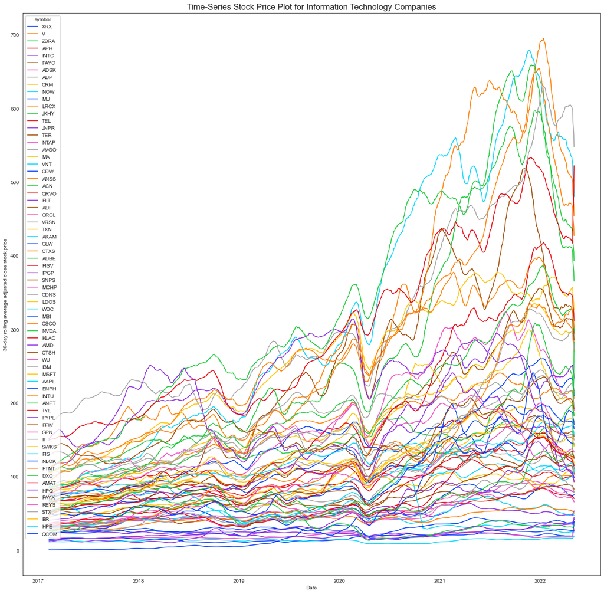

```python
plt.figure(figsize = (20, 20))
sns.lineplot(x="date", y = '30day_ave_close', hue="symbol", palette = 'bright', data = df6_1)
plt.xlabel('Date')
plt.ylabel('30-day rolling average adjusted close stock price')
plt.title('Time-Series Stock Price Plot for Information Technology Companies', fontsize = 16)
plt.show()
# plt.savefig('Figure16.png')
```

```python
df6_2 = df6[df6['sector'] == 'Industrials']
```

```python
## Commented to save space in the final report
# plt.figure(figsize = (20, 20))
# sns.lineplot(x="date", y = '30day_ave_close', hue="symbol", palette = 'bright', data = df6_2)
# plt.xlabel('Date')
# plt.ylabel('30-day rolling average adjusted close stock price')
# plt.title('Time-Series Stock Price Plot for Industrials Companies', fontsize = 16)
# plt.show()
```

```python
df6_3 = df6[df6['sector'] == 'Financials']
```

```python
## Commented to save space in the final report
# plt.figure(figsize = (20, 18))
# sns.lineplot(x="date", y = '30day_ave_close', hue="symbol", palette = 'bright', data = df6_3)
# plt.xlabel('Date')
# plt.ylabel('30-day rolling average adjusted close stock price')
# plt.title('Time-Series Stock Price Plot for Financials Companies', fontsize = 16)
# plt.show()
```

```python
df6_4 = df6[df6['sector'] == 'Health Care']
```

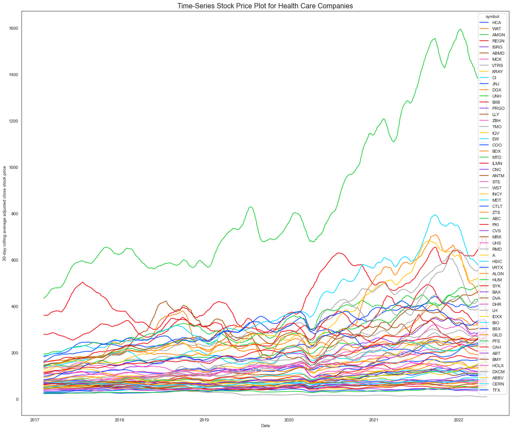

```python
plt.figure(figsize = (20, 17))
sns.lineplot(x="date", y = '30day_ave_close', hue="symbol", palette = 'bright', data = df6_4)
plt.xlabel('Date')
plt.ylabel('30-day rolling average adjusted close stock price')
plt.title('Time-Series Stock Price Plot for Health Care Companies', fontsize = 16)
plt.show()
# plt.savefig('Figure17.png')
```

```python
df6_5 = df6[df6['sector'] == 'Consumer Discretionary']
```

```python
## Commented to save space in the final report
# plt.figure(figsize = (20, 17))
# sns.lineplot(x="date", y = '30day_ave_close', hue="symbol", palette = 'bright', data = df6_5)
# plt.xlabel('Date')
# plt.ylabel('30-day rolling average adjusted close stock price')
# plt.title('Time-Series Stock Price Plot for Consumer Discretionary Companies', fontsize = 16)
# plt.show()
```

```python
df6_6 = df6[df6['sector'] == 'Consumer Staples']
```

```python
## Commented to save space in the final report
# plt.figure(figsize = (20, 12))
# sns.lineplot(x="date", y = '30day_ave_close', hue="symbol", palette = 'bright', data = df6_6)
# plt.xlabel('Date')
# plt.ylabel('30-day rolling average adjusted close stock price')
# plt.title('Time-Series Stock Price Plot for Consumer Staples Companies', fontsize = 16)
# plt.show()
```

```python
df6_7 = df6[df6['sector'] == 'Real Estate']
```

```python
## Commented to save space in the final report
# plt.figure(figsize = (20, 12))
# sns.lineplot(x="date", y = '30day_ave_close', hue="symbol", palette = 'bright', data = df6_7)
# plt.xlabel('Date')
# plt.ylabel('30-day rolling average adjusted close stock price')
# plt.title('Time-Series Stock Price Plot for Real Estate Companies', fontsize = 16)
# plt.show()
```

```python
df6_8 = df6[df6['sector'] == 'Materials']
```

```python
# plt.figure(figsize = (20, 12))
# sns.lineplot(x="date", y = '30day_ave_close', hue="symbol", palette = 'bright', data = df6_8)
# plt.xlabel('Date')
# plt.ylabel('30-day rolling average adjusted close stock price')
# plt.title('Time-Series Stock Price Plot for Materials Companies', fontsize = 16)
# plt.show()
```

```python
df6_9 = df6[df6['sector'] == 'Utilities']
```

```python
## Commented to save space in the final report
# plt.figure(figsize = (20, 12))
# sns.lineplot(x="date", y = '30day_ave_close', hue="symbol", palette = 'bright', data = df6_9)
# plt.xlabel('Date')
# plt.ylabel('30-day rolling average adjusted close stock price')
# plt.title('Time-Series Stock Price Plot for Utilities Companies', fontsize = 16)
# plt.show()
```

```python
df6_10 = df6[df6['sector'] == 'Communication Services']
```

```python
## Commented to save space in the final report
# plt.figure(figsize = (20, 10))
# sns.lineplot(x="date", y = '30day_ave_close', hue="symbol", palette = 'bright', data = df6_10)
# plt.xlabel('Date')
# plt.ylabel('30-day rolling average adjusted close stock price')
# plt.title('Time-Series Stock Price Plot for Communication Services Companies', fontsize = 16)
# plt.show()
```

```python
df6_11 = df6[df6['sector'] == 'Energy']
```

```python
## Commented to save space in the final report
# plt.figure(figsize = (20, 10))
# sns.lineplot(x="date", y = '30day_ave_close', hue="symbol", palette = 'bright', data = df6_11)
# plt.xlabel('Date')
# plt.ylabel('30-day rolling average adjusted close stock price')
# plt.title('Time-Series Stock Price Plot for Energy Companies', fontsize = 16)
# plt.show()
```

**From time-series plots of companies' stock prices by sector, we could detect that the stock price change tendencies among the same sector are very similar. Also, companies' stock price change tendencies among different sectors tend to be different.**

## Data Analysis 7 -- Exploring the Stock Price for 15 Companies with Highest Level of Sale in China

### Data Extraction

```python
%%sql result_set7 <<
select fort.symbol, t20level.companyname, fort.date, fort.adjustedclose, spg.sector, spg.industry
from fortune500stockprice fort
inner join TOP20Companies_LevelofSaleinChina t20level
on fort.symbol = t20level.symbol
inner join sp500withGICS spg
on t20level.symbol = spg.symbol
where date >= '2017-01-01';
```

```
 * postgresql://postgres:***@127.0.0.1:5433/6354Database
20145 rows affected.
Returning data to local variable result_set7
```

```python
df7 = result_set7.DataFrame()
```

```python
df7['date'] = df7['date'].astype('datetime64')
df7['adjustedclose'] = df7['adjustedclose'].astype('float')
df7.info()
```

```
<class 'pandas.core.frame.DataFrame'>
RangeIndex: 20145 entries, 0 to 20144
Data columns (total 6 columns):
 #   Column         Non-Null Count  Dtype
---  ------         --------------  -----
 0   symbol         20145 non-null  object
 1   companyname    20145 non-null  object
 2   date           20145 non-null  datetime64[ns]
 3   adjustedclose  20145 non-null  float64
 4   sector         20145 non-null  object
 5   industry       20145 non-null  object
dtypes: datetime64[ns](1), float64(1), object(4)
memory usage: 944.4+ KB
```

```python
df7['symbol'].unique()
```

```
array(['APH', 'INTC', 'MU', 'AVGO', 'TXN', 'GLW', 'WDC', 'AAPL', 'MMM',
       'BA', 'PG', 'AMAT', 'ABT', 'NKE', 'QCOM'], dtype=object)
```

```python
df7.companyname.unique()
```

```
array(['Amphenol Corp. Class A', 'Intel Corp.', 'Micron Technology Inc.',
       'Broadcom Ltd.', 'Texas Instruments Inc.', 'Corning Inc',
       'Western Digital Corp.', 'Apple Inc.', '3M co.', 'Boeing Co.',
       'Procter & Gamble co.', 'Applied Materials Inc.',
       'Abbott Laboratories', 'Nike Inc. Class B', 'Qualcomm Inc.'],
      dtype=object)
```

```python
s1 = pd.Series(df7['symbol'].unique())
s2 = pd.Series(df7.companyname.unique())
company_list = zip(s1, s2)
list(company_list)
```

```
[('APH', 'Amphenol Corp. Class A'),
 ('INTC', 'Intel Corp.'),
 ('MU', 'Micron Technology Inc.'),
 ('AVGO', 'Broadcom Ltd.'),
 ('TXN', 'Texas Instruments Inc.'),
 ('GLW', 'Corning Inc'),
 ('WDC', 'Western Digital Corp.'),
 ('AAPL', 'Apple Inc.'),
 ('MMM', '3M co.'),
 ('BA', 'Boeing Co.'),
 ('PG', 'Procter & Gamble co.'),
 ('AMAT', 'Applied Materials Inc.'),
 ('ABT', 'Abbott Laboratories'),
 ('NKE', 'Nike Inc. Class B'),
 ('QCOM', 'Qualcomm Inc.')]
```

### Data Visualization

#### Plot for Stock Price of 15 Companies with Highest Level of Sale in China by Company

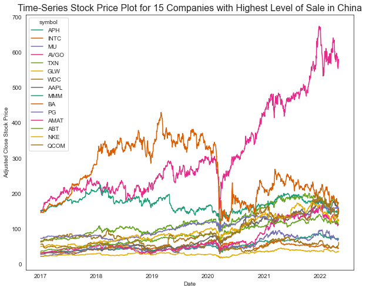

```python
plt.figure(figsize = (10, 8))
sns.lineplot(x="date", y = 'adjustedclose', hue="symbol", palette = 'Dark2', data = df7)
plt.xlabel('Date')
plt.ylabel('Adjusted Close Stock Price')
plt.title('Time-Series Stock Price Plot for 15 Companies with Highest Level of Sale in China', fontsize = 16)
plt.show()
# plt.savefig('Figure18.png')
```

#### Plot for Stock Price of 15 Companies with Highest Level of Sale in China by Sector

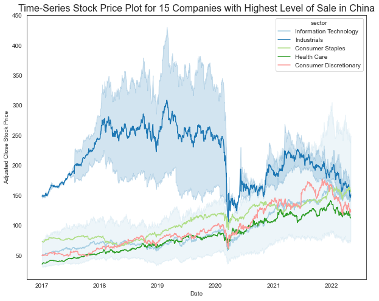

```python
plt.figure(figsize = (10, 8))
sns.lineplot(x="date", y = 'adjustedclose', hue="sector", palette = 'Paired', data = df7)
plt.xlabel('Date')
plt.ylabel('Adjusted Close Stock Price')
plt.title('Time-Series Stock Price Plot for 15 Companies with Highest Level of Sale in China', fontsize = 16)
plt.show()
# plt.savefig('Figure19.png')
```

**The 15 companies with the highest level of sales in China are mainly information technology companies, but a few companies from the other sectors, the stock price fluctuation tendency among different companies are quite different. After averaging the company stock price by sectors, we could detect that industrial companies' stock prices fluctuate most hugely and have a decreasing tendency during the trade war period, while the other companies' stock prices have an increasing tendency in general.**

### Data Analysis

```python
# Amphenol Corp. Class A
APH = df7[df7.symbol == 'APH'].set_index(['date'])
# Intel Corp.
INTC = df7[df7.symbol == 'INTC'].set_index(['date'])
# Micron Technology Inc.
MU = df7[df7.symbol == 'MU'].set_index(['date'])
# Broadcom Ltd.
AVGO = df7[df7.symbol == 'AVGO'].set_index(['date'])
# Texas Instruments Inc.
TXN = df7[df7.symbol == 'TXN'].set_index(['date'])
# Corning Inc
GLW = df7[df7.symbol == 'GLW'].set_index(['date'])
# Western Digital Corp.
WDC = df7[df7.symbol == 'WDC'].set_index(['date'])
# Apple Inc.
AAPL = df7[df7.symbol == 'AAPL'].set_index(['date'])
# 3M co.
MMM = df7[df7.symbol == 'MMM'].set_index(['date'])
# Boeing Co.
BA = df7[df7.symbol == 'BA'].set_index(['date'])
# Procter & Gamble co.
PG = df7[df7.symbol == 'PG'].set_index(['date'])
# Applied Materials Inc.
AMAT = df7[df7.symbol == 'AMAT'].set_index(['date'])
# Abbott Laboratories
ABT = df7[df7.symbol == 'ABT'].set_index(['date'])
# Nike Inc. Class B
NKE = df7[df7.symbol == 'NKE'].set_index(['date'])
# Qualcomm Inc.
QCOM = df7[df7.symbol == 'QCOM'].set_index(['date'])
```

#### Time Series Plot for Stock Price and Daily Changes of Stock Price

```python
import os
import sys

import pandas_datareader.data as web

import statsmodels.formula.api as smf
import statsmodels.tsa.api as smt
import statsmodels.api as sm
import scipy.stats as scs
import statsmodels.tsa as smta
from arch import arch_model

import matplotlib as mpl
%matplotlib inline
p = print
```

```python
def tsplot(y, lags=None, figsize=(10, 8), style='bmh'):
    if not isinstance(y, pd.Series):
        y = pd.Series(y)
    with plt.style.context(style):
        fig = plt.figure(figsize=figsize)
        #mpl.rcParams['font.family'] = 'Ubuntu Mono'
        layout = (2, 2)
        ts_ax = plt.subplot2grid(layout, (0, 0), colspan=2)
        acf_ax = plt.subplot2grid(layout, (1, 0))
        pacf_ax = plt.subplot2grid(layout, (1, 1))
        #qq_ax = plt.subplot2grid(layout, (2, 0))
        #pp_ax = plt.subplot2grid(layout, (2, 1))

        y.plot(ax=ts_ax)
        ts_ax.set_title('Time Series Analysis Plots')
        smt.graphics.plot_acf(y, lags=lags, ax=acf_ax, alpha=0.5)
        smt.graphics.plot_pacf(y, lags=lags, ax=pacf_ax, alpha=0.5)
        #sm.qqplot(y, line='s', ax=qq_ax)
        #qq_ax.set_title('QQ Plot')
        #scs.probplot(y, sparams=(y.mean(), y.std()), plot=pp_ax)

        plt.tight_layout()
    return
```

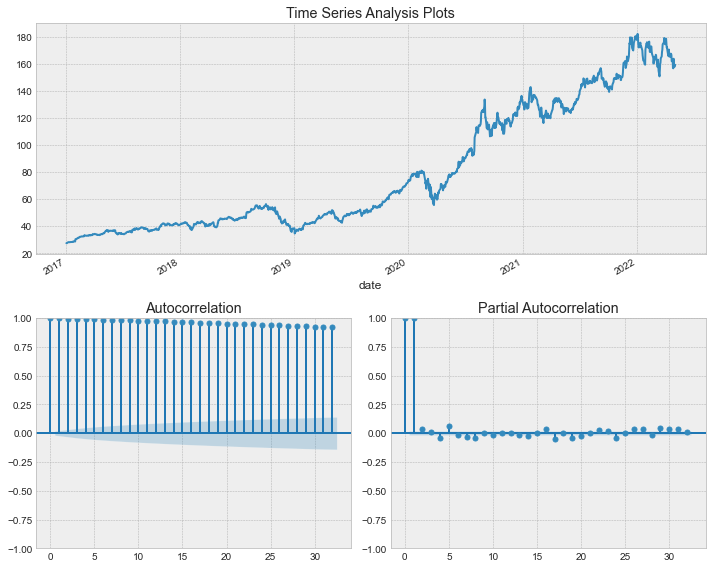

```python
tsplot(AAPL.adjustedclose)
# plt.savefig('Figure20.png')
```

**In reality, time-series stock data is always non-stationary; for example, the plot for Apple stock data above is non-stationary. And the autocorrelation (ACF) and partial autocorrelation (PACF) plots testify to the autocorrelation.**

**Next, I will do AD Fuller tests for each stock series to detect the stationarity.**

```python
# Compute the ADF for the companies' stock data to detect stationarity
# The null hypothesis for each test is that the stock data is non-stationarity
from statsmodels.tsa.stattools import adfuller
adf_APH = adfuller(APH.adjustedclose)
print('The p-value for the ADF test on APH is ', adf_APH[1])
adf_INTC = adfuller(INTC.adjustedclose)
print('The p-value for the ADF test on INTC is ', adf_INTC[1])
adf_MU = adfuller(MU.adjustedclose)
print('The p-value for the ADF test on MU is ', adf_MU[1])
adf_AVGO = adfuller(AVGO.adjustedclose)
print('The p-value for the ADF test on AVGO is ', adf_AVGO[1])
adf_TXN = adfuller(TXN.adjustedclose)
print('The p-value for the ADF test on TXN is ', adf_TXN[1])
adf_GLW = adfuller(GLW.adjustedclose)
print('The p-value for the ADF test on GLW is ', adf_GLW[1])
adf_WDC = adfuller(WDC.adjustedclose)
print('The p-value for the ADF test on WDC is ', adf_WDC[1])
adf_AAPL = adfuller(AAPL.adjustedclose)
print('The p-value for the ADF test on AAPL is ', adf_AAPL[1])
adf_MMM = adfuller(MMM.adjustedclose)
print('The p-value for the ADF test on MMM is ', adf_MMM[1])
adf_BA = adfuller(BA.adjustedclose)
print('The p-value for the ADF test on BA is ', adf_BA[1])
adf_PG = adfuller(PG.adjustedclose)
print('The p-value for the ADF test on PG is ', adf_PG[1])
adf_AMAT = adfuller(AMAT.adjustedclose)
print('The p-value for the ADF test on AMAT is ', adf_AMAT[1])
adf_ABT = adfuller(ABT.adjustedclose)
print('The p-value for the ADF test on ABT is ', adf_ABT[1])
adf_NKE = adfuller(NKE.adjustedclose)
print('The p-value for the ADF test on NKE is ', adf_NKE[1])
adf_QCOM = adfuller(QCOM.adjustedclose)
print('The p-value for the ADF test on QCOM is ', adf_QCOM[1])
```

```
The p-value for the ADF test on APH is  0.7806927548320779
The p-value for the ADF test on INTC is  0.11617598297062354
The p-value for the ADF test on MU is  0.4547967670790441
The p-value for the ADF test on AVGO is  0.9594796854371349
The p-value for the ADF test on TXN is  0.8104674553114753
The p-value for the ADF test on GLW is  0.31689572938294996
The p-value for the ADF test on WDC is  0.2567812379035717
The p-value for the ADF test on AAPL is  0.9679901691668595
The p-value for the ADF test on MMM is  0.17393968117077635
The p-value for the ADF test on BA is  0.4124168407482042
The p-value for the ADF test on PG is  0.9440275764100345
The p-value for the ADF test on AMAT is  0.8344203686797362
The p-value for the ADF test on ABT is  0.6978377846716866
The p-value for the ADF test on NKE is  0.6579612426694753
The p-value for the ADF test on QCOM is  0.7662105013199096
```

***From the results of ADF test, we could see all p-values are larger than 0.05, so we could not reject the null hypotheses, which leads to the conclusion that the stock data is non-stationary.***

**Working with non-stationary data is difficult. To model, we need to convert a non-stationary process to stationary.**

**First-difference is often used to convert a non-stationary process to stationary. And according to Dickey-Fuller Test, the first difference gives us stationary white noise w(t).**

```python
# Amphenol Corp. Class A
APH1d = np.diff(APH.adjustedclose)
# Intel Corp.
INTC1d = np.diff(INTC.adjustedclose)
# Micron Technology Inc.
MU1d = np.diff(MU.adjustedclose)
# Broadcom Ltd.
AVGO1d = np.diff(AVGO.adjustedclose)
# Texas Instruments Inc.
TXN1d = np.diff(TXN.adjustedclose)
# Corning Inc
GLW1d = np.diff(GLW.adjustedclose)
# Western Digital Corp.
WDC1d = np.diff(WDC.adjustedclose)
# Apple Inc.
AAPL1d = np.diff(AAPL.adjustedclose)
# 3M co.
MMM1d = np.diff(MMM.adjustedclose)
# Boeing Co.
BA1d = np.diff(BA.adjustedclose)
# Procter & Gamble co.
PG1d = np.diff(PG.adjustedclose)
# Applied Materials Inc.
AMAT1d = np.diff(AMAT.adjustedclose)
# Abbott Laboratories
ABT1d = np.diff(ABT.adjustedclose)
# Nike Inc. Class B
NKE1d = np.diff(NKE.adjustedclose)
# Qualcomm Inc.
QCOM1d = np.diff(QCOM.adjustedclose)
```

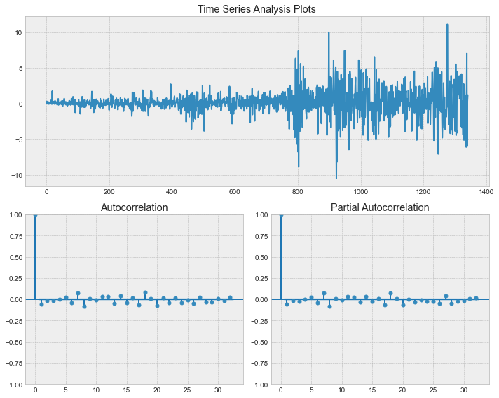

```python
tsplot(AAPL1d)
# plt.savefig('Figure21.png')
```

Taking Apple's first-difference stock data as an example, through the ACF and PACF plots above, we could detect that the non-stationary data has been processed into difference-stationary data, and the autocorrelation is constant over time. Also, the first-difference stock data shows how the daily changes of one company's stock price change along the timeline, which would be useful for us to explore the cointegration between different companies' operating status by their first-difference stock price.

Next, I will convert the stock price data into first-difference stock data for all companies and detect the correlations among different first-difference stock data.

```python
dic = {'APH1d': APH1d,
       'INTC1d': INTC1d,
       'MU1d': MU1d,
       'AVGO1d': AVGO1d,
       'TXN1d': TXN1d,
       'GLW1d': GLW1d,
       'WDC1d': WDC1d,
       'AAPL1d': AAPL1d,
       'MMM1d': MMM1d,
       'BA1d': BA1d,
       'PG1d': PG1d,
       'AMAT1d': AMAT1d,
       'ABT1d': ABT1d,
       'NKE1d': NKE1d,
       'QCOM1d': QCOM1d}

diff_stock1 = pd.DataFrame(dic).set_index(APH.index[1:])
```

```python
diff_stock1.corr()
```

|  | APH1d | INTC1d | MU1d | AVGO1d | TXN1d | GLW1d | WDC1d | AAPL1d | MMM1d | BA1d | PG1d | AMAT1d | ABT1d | NKE1d | QCOM1d |
| --- | --- | --- | --- | --- | --- | --- | --- | --- | --- | --- | --- | --- | --- | --- | --- |
| APH1d | 1.000000 | 0.554443 | 0.586354 | 0.682525 | 0.695802 | 0.687701 | 0.515437 | 0.577050 | 0.529536 | 0.506577 | 0.403491 | 0.635977 | 0.484340 | 0.547721 | 0.593024 |
| INTC1d | 0.554443 | 1.000000 | 0.568658 | 0.537787 | 0.635236 | 0.491718 | 0.477131 | 0.462769 | 0.406278 | 0.404452 | 0.320036 | 0.536106 | 0.426510 | 0.341716 | 0.473530 |
| MU1d | 0.586354 | 0.568658 | 1.000000 | 0.610272 | 0.663791 | 0.477479 | 0.675265 | 0.452169 | 0.328463 | 0.385651 | 0.215110 | 0.707532 | 0.321977 | 0.407201 | 0.557458 |
| AVGO1d | 0.682525 | 0.537787 | 0.610272 | 1.000000 | 0.732737 | 0.515984 | 0.454706 | 0.626259 | 0.330900 | 0.364109 | 0.262114 | 0.693326 | 0.419737 | 0.419180 | 0.669334 |
| TXN1d | 0.695802 | 0.635236 | 0.663791 | 0.732737 | 1.000000 | 0.595286 | 0.503309 | 0.579147 | 0.405305 | 0.385474 | 0.340874 | 0.723983 | 0.450565 | 0.447785 | 0.641393 |
| GLW1d | 0.687701 | 0.491718 | 0.477479 | 0.515984 | 0.595286 | 1.000000 | 0.453816 | 0.421575 | 0.534043 | 0.442728 | 0.323734 | 0.486482 | 0.408717 | 0.424017 | 0.448999 |
| WDC1d | 0.515437 | 0.477131 | 0.675265 | 0.454706 | 0.503309 | 0.453816 | 1.000000 | 0.321376 | 0.371951 | 0.394987 | 0.209516 | 0.498751 | 0.262745 | 0.347887 | 0.371309 |
| AAPL1d | 0.577050 | 0.462769 | 0.452169 | 0.626259 | 0.579147 | 0.421575 | 0.321376 | 1.000000 | 0.290707 | 0.325890 | 0.339192 | 0.531770 | 0.430177 | 0.427189 | 0.579035 |
| MMM1d | 0.529536 | 0.406278 | 0.328463 | 0.330900 | 0.405305 | 0.534043 | 0.371951 | 0.290707 | 1.000000 | 0.420525 | 0.368972 | 0.263141 | 0.379677 | 0.359714 | 0.251334 |
| BA1d | 0.506577 | 0.404452 | 0.385651 | 0.364109 | 0.385474 | 0.442728 | 0.394987 | 0.325890 | 0.420525 | 1.000000 | 0.229176 | 0.343780 | 0.276824 | 0.369038 | 0.298859 |
| PG1d | 0.403491 | 0.320036 | 0.215110 | 0.262114 | 0.340874 | 0.323734 | 0.209516 | 0.339192 | 0.368972 | 0.229176 | 1.000000 | 0.214167 | 0.488965 | 0.324010 | 0.250163 |
| AMAT1d | 0.635977 | 0.536106 | 0.707532 | 0.693326 | 0.723983 | 0.486482 | 0.498751 | 0.531770 | 0.263141 | 0.343780 | 0.214167 | 1.000000 | 0.319375 | 0.379573 | 0.660180 |
| ABT1d | 0.484340 | 0.426510 | 0.321977 | 0.419737 | 0.450565 | 0.408717 | 0.262745 | 0.430177 | 0.379677 | 0.276824 | 0.488965 | 0.319375 | 1.000000 | 0.369688 | 0.343556 |
| NKE1d | 0.547721 | 0.341716 | 0.407201 | 0.419180 | 0.447785 | 0.424017 | 0.347887 | 0.427189 | 0.359714 | 0.369038 | 0.324010 | 0.379573 | 0.369688 | 1.000000 | 0.405742 |
| QCOM1d | 0.593024 | 0.473530 | 0.557458 | 0.669334 | 0.641393 | 0.448999 | 0.371309 | 0.579035 | 0.251334 | 0.298859 | 0.250163 | 0.660180 | 0.343556 | 0.405742 | 1.000000 |

```python
# Use AD Fuller test to detect cointegration among two sample first-difference stock price
from statsmodels.tsa.stattools import adfuller
adf1 = adfuller(MU1d - PG1d)
print('The p-value for the ADF test on the spread between MU and PG first-difference stock data is ', adf1[1])
```

```
The p-value for the ADF test on the spread between MU and PG first-difference stock data is  0.0
```

***Since p-value = 0 for the ADF test, we could reject the null hypothesis and conclude that the first-difference stock data of MU and PG are cointegrated with more than 99% certainty.***

## Data Analysis 8 -- Exploring the Stock Price for Top 12 Companies with Highest Share of Sale in China

### Data Extraction

```python
%%sql result_set8 <<
select fort.symbol, t20share.companyname, fort.date, fort.adjustedclose, spg.sector, spg.industry
from fortune500stockprice fort
inner join TOP20Companies_ShareofSaleinChina t20share
on fort.symbol = t20share.symbol
inner join SP500withGICS spg
on t20share.symbol = spg.symbol
where date >= '2017-01-01';
```

```
 * postgresql://postgres:***@127.0.0.1:5433/6354Database
16116 rows affected.
Returning data to local variable result_set8
```

```python
df8 = result_set8.DataFrame()
df8['date'] = df8['date'].astype('datetime64')
df8['adjustedclose'] = df8['adjustedclose'].astype('float')
df8.info()
```

```
<class 'pandas.core.frame.DataFrame'>
RangeIndex: 16116 entries, 0 to 16115
Data columns (total 6 columns):
 #   Column         Non-Null Count  Dtype
---  ------         --------------  -----
 0   symbol         16116 non-null  object
 1   companyname    16116 non-null  object
 2   date           16116 non-null  datetime64[ns]
 3   adjustedclose  16116 non-null  float64
 4   sector         16116 non-null  object
 5   industry       16116 non-null  object
dtypes: datetime64[ns](1), float64(1), object(4)
memory usage: 755.6+ KB
```

```python
df8.symbol.unique()
```

```
array(['APH', 'INTC', 'MU', 'AVGO', 'TXN', 'GLW', 'WDC', 'NVDA', 'AMD',
       'AAPL', 'AMAT', 'QCOM'], dtype=object)
```

```python
df8.companyname.unique()
```

```
array(['Amphenol Corp. Class A', 'Intel Corp.', 'Micron Technology Inc.',
       'Broadcom Ltd.', 'Texas Instruments Inc.', 'Corning Inc',
       'Western Digital Corp.', 'Nvidia Corp.',
       'Advanced Micro Devices Inc.', 'Apple Inc.',
       'Applied Materials Inc.', 'Qualcomm Inc.'], dtype=object)
```

```python
s3 = pd.Series(df8['symbol'].unique())
s4 = pd.Series(df8.companyname.unique())
company_list2 = zip(s3, s4)
list(company_list2)
```

```
[('APH', 'Amphenol Corp. Class A'),
 ('INTC', 'Intel Corp.'),
 ('MU', 'Micron Technology Inc.'),
 ('AVGO', 'Broadcom Ltd.'),
 ('TXN', 'Texas Instruments Inc.'),
 ('GLW', 'Corning Inc'),
 ('WDC', 'Western Digital Corp.'),
 ('NVDA', 'Nvidia Corp.'),
 ('AMD', 'Advanced Micro Devices Inc.'),
 ('AAPL', 'Apple Inc.'),
 ('AMAT', 'Applied Materials Inc.'),
 ('QCOM', 'Qualcomm Inc.')]
```

### Data Visualization

#### Time-Series Stock Price Plot for 12 Companies with Highest Share of Sale in China

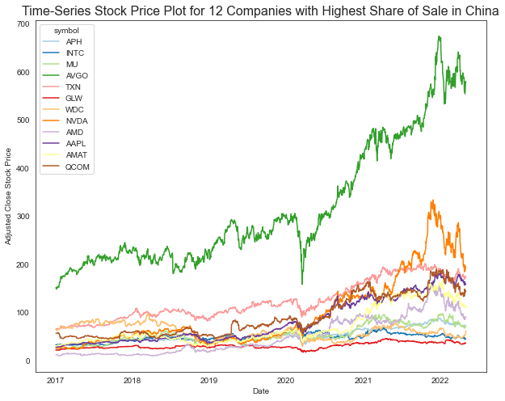

```python
plt.figure(figsize = (10, 8))
sns.lineplot(x="date", y = 'adjustedclose', hue="symbol", palette = 'Paired', data = df8)
plt.xlabel('Date')
plt.ylabel('Adjusted Close Stock Price')
plt.title('Time-Series Stock Price Plot for 12 Companies with Highest Share of Sale in China', fontsize = 16)
plt.show()
```

#### Time-Series Stock Price Plot for 12 Companies with Highest Share of Sale in China

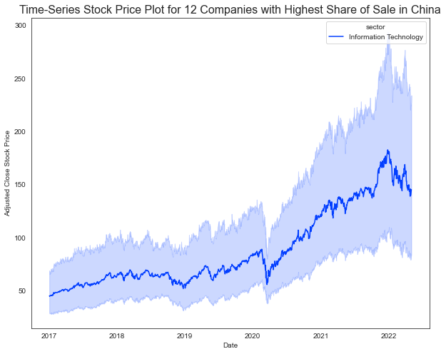

```python
plt.figure(figsize = (10, 8))
sns.lineplot(x="date", y = 'adjustedclose', hue="sector", palette = 'bright', data = df8)
plt.xlabel('Date')
plt.ylabel('Adjusted Close Stock Price')
plt.title('Time-Series Stock Price Plot for 12 Companies with Highest Share of Sale in China', fontsize = 16)
plt.show()
```

**The 12 companies with the highest share of sales in China are almost information technology companies. And the stock price change tendencies tend to be similar.**

### Data Analysis

```python
# Amphenol Corp. Class A
APH = df8[df8.symbol == 'APH'].set_index(['date'])
# Intel Corp.
INTC = df8[df8.symbol == 'INTC'].set_index(['date'])
# Micron Technology Inc.
MU = df8[df8.symbol == 'MU'].set_index(['date'])
# Broadcom Ltd.
AVGO = df8[df8.symbol == 'AVGO'].set_index(['date'])
# Texas Instruments Inc.
TXN = df8[df8.symbol == 'TXN'].set_index(['date'])
# Corning Inc
GLW = df8[df8.symbol == 'GLW'].set_index(['date'])
# Western Digital Corp.
WDC = df8[df8.symbol == 'WDC'].set_index(['date'])
# Nvidia Corp.
NVDA = df8[df8.symbol == 'NVDA'].set_index(['date'])
# Advanced Micro Devices Inc.
AMD = df8[df8.symbol == 'AMD'].set_index(['date'])
# Apple Inc.
AAPL = df8[df8.symbol == 'AAPL'].set_index(['date'])
# Applied Materials Inc.
AMAT = df8[df8.symbol == 'AMAT'].set_index(['date'])
# Qualcomm Inc.
QCOM = df8[df8.symbol == 'QCOM'].set_index(['date'])
```

```python
# Amphenol Corp. Class A
APH1d = np.diff(APH.adjustedclose)
# Intel Corp.
INTC1d = np.diff(INTC.adjustedclose)
# Micron Technology Inc.
MU1d = np.diff(MU.adjustedclose)
# Broadcom Ltd.
AVGO1d = np.diff(AVGO.adjustedclose)
# Texas Instruments Inc.
TXN1d = np.diff(TXN.adjustedclose)
# Corning Inc
GLW1d = np.diff(GLW.adjustedclose)
# Western Digital Corp.
WDC1d = np.diff(WDC.adjustedclose)
# Nvidia Corp.
NVDA1d = np.diff(NVDA.adjustedclose)
# Advanced Micro Devices Inc.
AMD1d = np.diff(AMD.adjustedclose)
# Apple Inc.
AAPL1d = np.diff(AAPL.adjustedclose)
# Applied Materials Inc.
AMAT1d = np.diff(AMAT.adjustedclose)
# Qualcomm Inc.
QCOM1d = np.diff(QCOM.adjustedclose)
```

```python
dic2 = {'APH1d': APH1d,
       'INTC1d': INTC1d,
       'MU1d': MU1d,
       'AVGO1d': AVGO1d,
       'TXN1d': TXN1d,
       'GLW1d': GLW1d,
       'WDC1d': WDC1d,
       'NVDA1d': NVDA1d,
       'AMD1d': AMD1d,
       'AAPL1d': AAPL1d,
       'AMAT1d': AMAT1d,
       'QCOM1d': QCOM1d}

diff_stock2 = pd.DataFrame(dic2).set_index(APH.index[1:])
```

```python
diff_stock2.corr()
```

|  | APH1d | INTC1d | MU1d | AVGO1d | TXN1d | GLW1d | WDC1d | NVDA1d | AMD1d | AAPL1d | AMAT1d | QCOM1d |
| --- | --- | --- | --- | --- | --- | --- | --- | --- | --- | --- | --- | --- |
| APH1d | 1.000000 | 0.554443 | 0.586354 | 0.682525 | 0.695802 | 0.687701 | 0.515437 | 0.512636 | 0.476918 | 0.577050 | 0.635977 | 0.593024 |
| INTC1d | 0.554443 | 1.000000 | 0.568658 | 0.537787 | 0.635236 | 0.491718 | 0.477131 | 0.385342 | 0.342456 | 0.462769 | 0.536106 | 0.473530 |
| MU1d | 0.586354 | 0.568658 | 1.000000 | 0.610272 | 0.663791 | 0.477479 | 0.675265 | 0.517104 | 0.487191 | 0.452169 | 0.707532 | 0.557458 |
| AVGO1d | 0.682525 | 0.537787 | 0.610272 | 1.000000 | 0.732737 | 0.515984 | 0.454706 | 0.624587 | 0.566220 | 0.626259 | 0.693326 | 0.669334 |
| TXN1d | 0.695802 | 0.635236 | 0.663791 | 0.732737 | 1.000000 | 0.595286 | 0.503309 | 0.572283 | 0.537589 | 0.579147 | 0.723983 | 0.641393 |
| GLW1d | 0.687701 | 0.491718 | 0.477479 | 0.515984 | 0.595286 | 1.000000 | 0.453816 | 0.328301 | 0.326096 | 0.421575 | 0.486482 | 0.448999 |
| WDC1d | 0.515437 | 0.477131 | 0.675265 | 0.454706 | 0.503309 | 0.453816 | 1.000000 | 0.291919 | 0.276868 | 0.321376 | 0.498751 | 0.371309 |
| NVDA1d | 0.512636 | 0.385342 | 0.517104 | 0.624587 | 0.572283 | 0.328301 | 0.291919 | 1.000000 | 0.750125 | 0.584230 | 0.641828 | 0.633838 |
| AMD1d | 0.476918 | 0.342456 | 0.487191 | 0.566220 | 0.537589 | 0.326096 | 0.276868 | 0.750125 | 1.000000 | 0.544282 | 0.586245 | 0.605426 |
| AAPL1d | 0.577050 | 0.462769 | 0.452169 | 0.626259 | 0.579147 | 0.421575 | 0.321376 | 0.584230 | 0.544282 | 1.000000 | 0.531770 | 0.579035 |
| AMAT1d | 0.635977 | 0.536106 | 0.707532 | 0.693326 | 0.723983 | 0.486482 | 0.498751 | 0.641828 | 0.586245 | 0.531770 | 1.000000 | 0.660180 |
| QCOM1d | 0.593024 | 0.473530 | 0.557458 | 0.669334 | 0.641393 | 0.448999 | 0.371309 | 0.633838 | 0.605426 | 0.579035 | 0.660180 | 1.000000 |

**Data Analysis 7 and 8 show a similar phenomenon the stock price of the companies in the list of top 20 companies with the highest level of sales in China and the list of top 20 companies with the highest share of sales in China are highly cointegrated. Since stock prices are sensitive to many specific issues and when the first-difference stock prices of multiple companies are highly cointegrated, we could suppose that some common factors affect the companies, such as the U.S.-China trade war.**

**To explore whether the U.S.-China affects only the companies exposed to China or all types of MNCs, I extract the stock price of another list of 12 companies randomly selected from the S&P 500 company list. The 12 companies cover multiple sectors.**

## Data Analysis 9 -- Exploring the Stock Price for 12 Companies Randomly Selected from the S&P 500 Company List

```python
all_stock = result_set6.DataFrame()
#all_stock['30day_ave_close'] = all_stock.adjustedclose.rolling(30).mean().shift(-3)
#all_stock = all_stock[all_stock['date'] >= '2017-02-09']
all_stock['date'] = all_stock['date'].astype('datetime64')
all_stock['adjustedclose'] = all_stock['adjustedclose'].astype('float')
```

```python
## Extract stock price time-series data for each company in the sample
# Google
GOOG = all_stock[all_stock.symbol == 'GOOG'].set_index(['date'])
# Facebook (Meta)
FB = all_stock[all_stock.symbol == 'FB'].set_index(['date'])
# JPMorgan Chase & Co
JPM = all_stock[all_stock.symbol == 'JPM'].set_index(['date'])
# Bank of America Corp
BAC = all_stock[all_stock.symbol == 'BAC'].set_index(['date'])
# Cincinnati Financial -- Financials company
CINF = all_stock[all_stock.symbol == 'CINF'].set_index(['date'])
# Discover Financial Services -- Financials company
DFS = all_stock[all_stock.symbol == 'DFS'].set_index(['date'])
# Duke Realty Corp -- Real Estate
DRE = all_stock[all_stock.symbol == 'DRE'].set_index(['date'])
# Healthpeak Properties -- Real Estate
PEAK = all_stock[all_stock.symbol == 'PEAK'].set_index(['date'])
# Hormel Foods Corp. -- Consumer Staples
HRL = all_stock[all_stock.symbol == 'HRL'].set_index(['date'])
# Lamb Weston Holdings Inc -- Consumer Staples
LW = all_stock[all_stock.symbol == 'LW'].set_index(['date'])
# Las Vegas Sands -- Consumer Discretionary
LVS = all_stock[all_stock.symbol == 'LVS'].set_index(['date'])
# Marriott Int'l. -- Consumer Discretionary
MAR = all_stock[all_stock.symbol == 'MAR'].set_index(['date'])
```

```python
adf_APH = adfuller(GOOG.adjustedclose)
print('The p-value for the ADF test on GOOG is ', adf_APH[1])
adf_INTC = adfuller(FB.adjustedclose)
print('The p-value for the ADF test on FB is ', adf_INTC[1])
adf_MU = adfuller(JPM.adjustedclose)
print('The p-value for the ADF test on JPM is ', adf_MU[1])
adf_AVGO = adfuller(BAC.adjustedclose)
print('The p-value for the ADF test on BAC is ', adf_AVGO[1])
adf_TXN = adfuller(CINF.adjustedclose)
print('The p-value for the ADF test on CINF is ', adf_TXN[1])
adf_GLW = adfuller(DFS.adjustedclose)
print('The p-value for the ADF test on DFS is ', adf_GLW[1])
adf_WDC = adfuller(DRE.adjustedclose)
print('The p-value for the ADF test on DRE is ', adf_WDC[1])
adf_AAPL = adfuller(PEAK.adjustedclose)
print('The p-value for the ADF test on PEAK is ', adf_AAPL[1])
adf_MMM = adfuller(HRL.adjustedclose)
print('The p-value for the ADF test on HRL is ', adf_MMM[1])
adf_BA = adfuller(LW.adjustedclose)
print('The p-value for the ADF test on LW is ', adf_BA[1])
adf_PG = adfuller(LVS.adjustedclose)
print('The p-value for the ADF test on LVS is ', adf_PG[1])
adf_AMAT = adfuller(MAR.adjustedclose)
print('The p-value for the ADF test on MAR is ', adf_AMAT[1])
```

```
The p-value for the ADF test on GOOG is  0.9206452216305152
The p-value for the ADF test on FB is  0.4408830489570079
The p-value for the ADF test on JPM is  0.5164123596562111
The p-value for the ADF test on BAC is  0.527076862960515
The p-value for the ADF test on CINF is  0.6181210041301123
The p-value for the ADF test on DFS is  0.8236884846098547
The p-value for the ADF test on DRE is  0.9630232739124333
The p-value for the ADF test on PEAK is  0.7101643261104784
The p-value for the ADF test on HRL is  0.7724075446506207
The p-value for the ADF test on LW is  0.07904250900005483
The p-value for the ADF test on LVS is  0.17728913574082866
The p-value for the ADF test on MAR is  0.29830008378976064
```

***From the results of ADF test above, we could see all p-values are larger than 0.05, so we could not reject the null hypotheses, which leads to the conclusion that the stock data for the above companies are also non-stationary.***

**Next, I will take the first-difference of each stock price data.**

```python
# Amphenol Corp. Class A
GOOG1d = np.diff(GOOG.adjustedclose)
# Intel Corp.
FB1d = np.diff(FB.adjustedclose)
# Micron Technology Inc.
JPM1d = np.diff(JPM.adjustedclose)
# Broadcom Ltd.
BAC1d = np.diff(BAC.adjustedclose)
# Texas Instruments Inc.
CINF1d = np.diff(CINF.adjustedclose)
# Corning Inc
DFS1d = np.diff(DFS.adjustedclose)
# Western Digital Corp.
DRE1d = np.diff(DRE.adjustedclose)
# Apple Inc.
PEAK1d = np.diff(PEAK.adjustedclose)
# 3M co.
HRL1d = np.diff(HRL.adjustedclose)
# Boeing Co.
LW1d = np.diff(LW.adjustedclose)
# Procter & Gamble co.
LVS1d = np.diff(LVS.adjustedclose)
# Applied Materials Inc.
MAR1d = np.diff(MAR.adjustedclose)
```

```python
dic3 = {'GOOG1d': GOOG1d,
       'FB1d': FB1d,
       'JPM1d': JPM1d,
       'BAC1d': BAC1d,
       'CINF1d': CINF1d,
       'DFS1d': DFS1d,
       'DRE1d': DRE1d,
       'PEAK1d': PEAK1d,
       'HRL1d': HRL1d,
       'LW1d': LW1d,
       'LVS1d': LVS1d,
       'MAR1d': MAR1d}

diff_stock3 = pd.DataFrame(dic3).set_index(GOOG.index[1:])
```

```python
diff_stock3.corr()
```

|  | GOOG1d | FB1d | JPM1d | BAC1d | CINF1d | DFS1d | DRE1d | PEAK1d | HRL1d | LW1d | LVS1d | MAR1d |
| --- | --- | --- | --- | --- | --- | --- | --- | --- | --- | --- | --- | --- |
| GOOG1d | 1.000000 | 0.622545 | 0.401207 | 0.407539 | 0.336213 | 0.409778 | 0.409614 | 0.314902 | 0.105119 | 0.272933 | 0.410428 | 0.415559 |
| FB1d | 0.622545 | 1.000000 | 0.262858 | 0.268749 | 0.186599 | 0.294676 | 0.295006 | 0.243506 | 0.075703 | 0.191262 | 0.318553 | 0.270208 |
| JPM1d | 0.401207 | 0.262858 | 1.000000 | 0.910234 | 0.633412 | 0.766945 | 0.392430 | 0.427986 | 0.149557 | 0.467209 | 0.530752 | 0.554273 |
| BAC1d | 0.407539 | 0.268749 | 0.910234 | 1.000000 | 0.614743 | 0.762158 | 0.357351 | 0.364705 | 0.142291 | 0.446114 | 0.520625 | 0.550728 |
| CINF1d | 0.336213 | 0.186599 | 0.633412 | 0.614743 | 1.000000 | 0.524034 | 0.513596 | 0.469031 | 0.303622 | 0.426689 | 0.328106 | 0.412689 |
| DFS1d | 0.409778 | 0.294676 | 0.766945 | 0.762158 | 0.524034 | 1.000000 | 0.331441 | 0.403606 | 0.074661 | 0.476002 | 0.510200 | 0.590446 |
| DRE1d | 0.409614 | 0.295006 | 0.392430 | 0.357351 | 0.513596 | 0.331441 | 1.000000 | 0.692310 | 0.372041 | 0.336983 | 0.259185 | 0.277077 |
| PEAK1d | 0.314902 | 0.243506 | 0.427986 | 0.364705 | 0.469031 | 0.403606 | 0.692310 | 1.000000 | 0.244895 | 0.458210 | 0.329508 | 0.366395 |
| HRL1d | 0.105119 | 0.075703 | 0.149557 | 0.142291 | 0.303622 | 0.074661 | 0.372041 | 0.244895 | 1.000000 | 0.166792 | 0.051794 | 0.029817 |
| LW1d | 0.272933 | 0.191262 | 0.467209 | 0.446114 | 0.426689 | 0.476002 | 0.336983 | 0.458210 | 0.166792 | 1.000000 | 0.387316 | 0.430735 |
| LVS1d | 0.410428 | 0.318553 | 0.530752 | 0.520625 | 0.328106 | 0.510200 | 0.259185 | 0.329508 | 0.051794 | 0.387316 | 1.000000 | 0.606739 |
| MAR1d | 0.415559 | 0.270208 | 0.554273 | 0.550728 | 0.412689 | 0.590446 | 0.277077 | 0.366395 | 0.029817 | 0.430735 | 0.606739 | 1.000000 |

```python
# Use AD Fuller test to detect cointegration among two sample first-difference stock price
from statsmodels.tsa.stattools import adfuller
adf1 = adfuller(GOOG1d - HRL1d)
print('The p-value for the ADF test on the spread between GOOG and HRL first-difference stock data is ', adf1[1])
```

```
The p-value for the ADF test on the spread between GOOG and HRL first-difference stock data is  7.498268890224783e-14
```

**Overall, through the stock price time series analysis, the first-difference stock price of most of the companies seems to be cointegrated. It shows they are all affected by the same factor. Combined with the stock price trend plots in the previous section, we could find evidence of the effect of U.S.-China trade war on most the companies in general.**

**The nine analysis examples above provide a perspective on how to utilize the database to do further exploration about U.S.-China trade war.**

# References

- Kapadia, Reshma. November 15, 2021. U.S. Companies Face New Risks in a Changing China. What That Means for the Stocks. https://www.barrons.com/articles/us-china-business-risks-stocks-51636707602. (Accessed Feb. 25, 2022)
- Shen, Guobing. Wang, Peijie. Xu, Yuanhan. 2021.Trade destruction and deflection effects of US-China trade frictions on China’s tariff-targeted Products. The World Economy. 44:2076–2106. https://doi.org/10.1111/twec.13067.
- Wang, Dong. June 16, 2013. U.S.-China Trade, 1971-2012: Insights into the U.S.-China. The Asian-Pacific Journal. Volume 11, Issue 24, Number 4. Article ID 3958.
- Wikipedia Foundation. (2021, November 10). China-United States Trade War. Wikipedia. Retrieved March 17, 2022, from https://en.wikipedia.org/wiki/China–United_States_trade_war.

# Data Sources

- Bown, Chad P. 2021. “The US–China Trade War and Phase One Agreement.” Journal of Policy Modeling 43(4): 805–43.
- Bown, Chad P. April 22, 2022. US-China Trade War Tariffs: An Up-to-Date Chart. https://www.piie.com/research/piie-charts/us-china-trade-war-tariffs-date-chart. (Accessed May 5, 2022)
- DATA Hub. 2021. S&P 500 Companies with Financial Information. https://datahub.io/core/s-and-p-500-companies#readme. (Accessed Mar. 9, 2022)
- Fortune 500 Company Revenue Data. Fortune. https://fortune.com/fortune500/2021/search/. (Accessed Mar. 18, 2022)
- Merlos. 2021. SP 500 GICS classification. https://www.kaggle.com/code/merlos/sp-500-gics-classification/data?select=sp500-with-gics.csv. (Accessed May 5, 2022)
- Yahoo!Finance. 2022. Yahoo stock price data. http://finance.yahoo.com/q/pr?s=MSFT. (Accessed May 3, 2022)
- Philip van Doorn. 2018. Apple, Nike and 18 other U.S. companies have \$158 billion at stake in China trade war – Tables top 20 U.S. companies among the S\&P 500 with the highest level of sales and top 20 U.S. companies in the S\&P 500 with the highest share of sales in China included.) https://www.marketwatch.com/story/trade-war-watch-these-are-the-us-companies-with-the-most-at-stake-in-china-2018-03-29. (Accessed Mar. 9, 2022)
- U.S. Census Bureau. 2022. U.S. International Trade Data – Trade in Goods with China. https://www.census.gov/foreign-trade/balance/c5700.html. (Accessed Feb. 24, 2022)
- United States International Trade Commission (USITC). Trade Data – General Imports, Total Exports, Trade Balance. https://dataweb.usitc.gov. (Accessed Mar. 9, 2022)
- World Bank. World Development Indicators. https://databank.worldbank.org/reports.aspx?dsid=2&series=NY.GDP.MKTP.CD. (Accessed Apr. 26, 2022)